# Análisis de delitos en CABA

## Proyecto final diplomatura Data Science

## Análisis de Patrones Temporales de Delitos en CABA (2019)

## Contenido

1. **Objetivo.**
2. **Relevancia del problema.**
3. **Herramientas y tecnologías utilizadas.**
4. **Datos disponibles.**
5. **Métodos de análisis.**
6. **Interpretación y Conclusiones.**

## Objetivo

El proyecto se enfoca en realizar un análisis de patrones temporales de delitos en la Ciudad de Buenos Aires (CABA) utilizando técnicas de ciencias de datos.  
Reconociendo la importancia crucial de comprender cómo varía la ocurrencia del crimen a lo largo del día y a lo largo de los años, nuestro objetivo principal es identificar tendencias significativas que puedan proporcionar a las autoridades locales una base sólida de información que les permita tomar decisiones informadas en materia de seguridad pública y planificación urbana.

## Relevancia del problema

En una metrópolis dinámica y densamente poblada, cómo en el caso de la Ciudad de Buenos Aires (CABA), entender cómo varían los delitos a lo largo del día y a lo largo del año resulta fundamental para diseñar estrategias efectivas de prevención del delito y aplicación de la ley.

Por un lado, comprender la relación entre el día de la semana, la hora del día y la ocurrencia de delitos puede ayudar a las autoridades a asignar recursos de manera más eficiente.  
Por ejemplo, si ciertos tipos de delitos tienden a aumentar durante ciertas horas del día o días de la semana, se pueden implementar patrullajes adicionales o medidas de seguridad específicas en esos momentos y lugares.  
Comprender los patrones temporales de delitos no solo es importante para mejorar la seguridad pública y la calidad de vida de los residentes, sino que también puede tener implicaciones más amplias para el diseño de políticas públicas, la planificación urbana y la asignación de recursos en la ciudad.  
Por lo tanto, este análisis no sólo es relevante desde una perspectiva académica, sino que también tiene implicaciones prácticas significativas para la gestión y la gobernanza de la ciudad.

## Herramientas y tecnologías utilizadas

- **Excel**
- **Lenguaje R**
- **Posit Cloud - Notebook R**
- **Librerías R: readxl, ggplot2, sf**

## Datos disponibles

Los datasets utilizados fueron extraidos de las fuentes oficiales “datos.gob.ar” y “data.buenosaires.gob.ar”, donde el gobierno nacional y el Ciudad Autónoma de Buenos Aires publican su información estadística.  
Los datos inicialmente abarcan los delitos registrados en cada distrito de la República Argentina, permitiendo así su desglose hasta el nivel de barrios y comunas dentro de la Ciudad Autónoma de Buenos Aires.  
Debido a limitaciones de memoria y CPU por el uso de una licencia gratuita del software Posit cloud para crear el Notebook R, se decidió acotar el estudio del data set para el periodo 2019 y el distrito de CABA.

## Métodos de análisis

**Análisis Exploratorio de Datos (EDA), para el cual se utilizará el lenguaje de progración R mediante las siguientes actividades:**

- **Preparación de datos:** partimos de datos limpios y extructurados almacenados en un archivo Excel para luego ser cargados en un Data Frame.

```r
library(readxl)
library(ggplot2)

#invisible(memory.limit(64000))  # Aumenta la memoria límite

#ruta_del_archivo <- "/cloud/project/DataSet/dataset_delitos2019.xlsx"
#datos_excel <- read_excel(ruta_del_archivo)

datos_excel <- read_excel("DataSet/dataset_delitos2019.xlsx",
    col_types = c("date", "numeric", "text",
                  "text", "numeric", "text", "numeric",
                  "numeric"))

mi_data_frame <- data.frame(datos_excel)
```

- **Verificar datos mediante resumén del Date Frame**

```r
summary(mi_data_frame)
```

```
##      fecha                     franja_horaria  tipo_delito
##  Min.   :2019-01-01 00:00:00   Min.   : 0.00   Length:122480
##  1st Qu.:2019-03-28 00:00:00   1st Qu.: 9.00   Class :character
##  Median :2019-06-27 00:00:00   Median :14.00   Mode  :character
##  Mean   :2019-06-29 00:28:06   Mean   :13.03
##  3rd Qu.:2019-09-29 00:00:00   3rd Qu.:19.00
##  Max.   :2019-12-31 00:00:00   Max.   :23.00
##  subtipo_delito     cantidad_registrada    barrio               lat
##  Length:122480      Min.   : 1.000      Length:122480      Min.   :-34.70
##  Class :character   1st Qu.: 1.000      Class :character   1st Qu.:-34.63
##  Mode  :character   Median : 1.000      Mode  :character   Median :-34.61
##                     Mean   : 1.014                         Mean   :-34.42
##                     3rd Qu.: 1.000                         3rd Qu.:-34.59
##                     Max.   :16.000                         Max.   :  0.00
##       long
##  Min.   :-58.53
##  1st Qu.:-58.47
##  Median :-58.43
##  Mean   :-58.10
##  3rd Qu.:-58.40
##  Max.   :  0.00
```

- *Análisis exploratorio de datos:*

  **Gráfico de Barras**

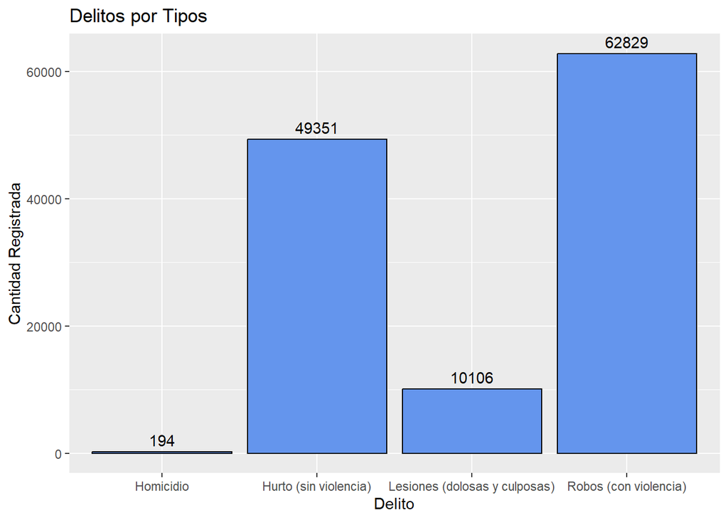

```r
ggplot(data = mi_data_frame, aes(tipo_delito)) +
  geom_bar(fill = "cornflowerblue",
           color="black") +
  geom_text(stat = "count", aes(label = after_stat(count)), vjust = -0.5) +
  labs(x = "Delito",
       y = "Cantidad Registrada",
       title = "Delitos por Tipos")
```

**Histogramas**

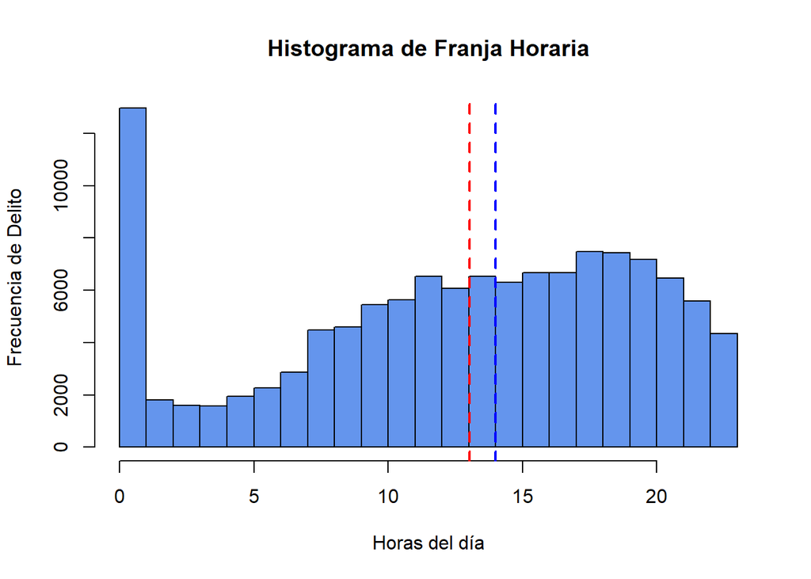

```r
hist(mi_data_frame$franja_horaria,col = "cornflowerblue",
     xlab = "Horas del día", ylab = "Frecuencia de Delito",
     main = "Histograma de Franja Horaria")

# Calcular la media y la mediana
media <- mean(mi_data_frame$franja_horaria)
mediana <- median(mi_data_frame$franja_horaria)

# Agregar líneas verticales para la media y la mediana
abline(v = media, col = "red", lwd = 2, lty = 2)
abline(v = mediana, col = "blue", lwd = 2, lty = 2)
```

```r
cat("Media:", media, "\n")
```

```
## Media: 13.03262
```

```r
cat("Mediana:", mediana, "\n")
```

```
## Mediana: 14
```

**Histograma por tipo de delito**

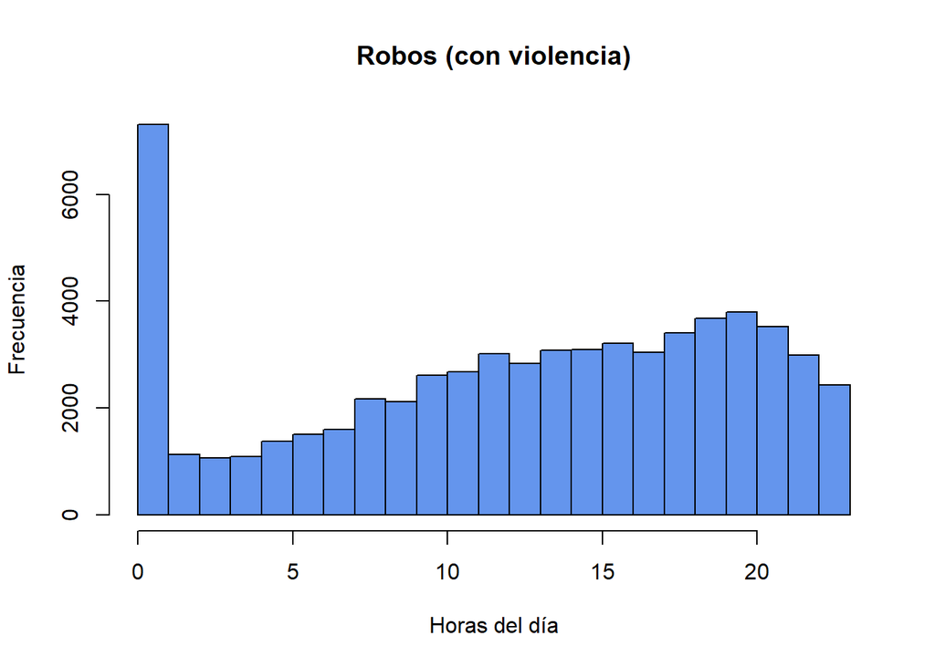

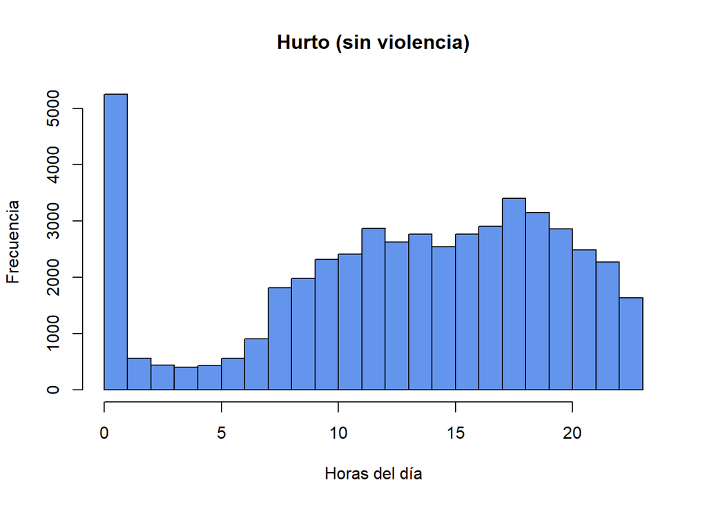

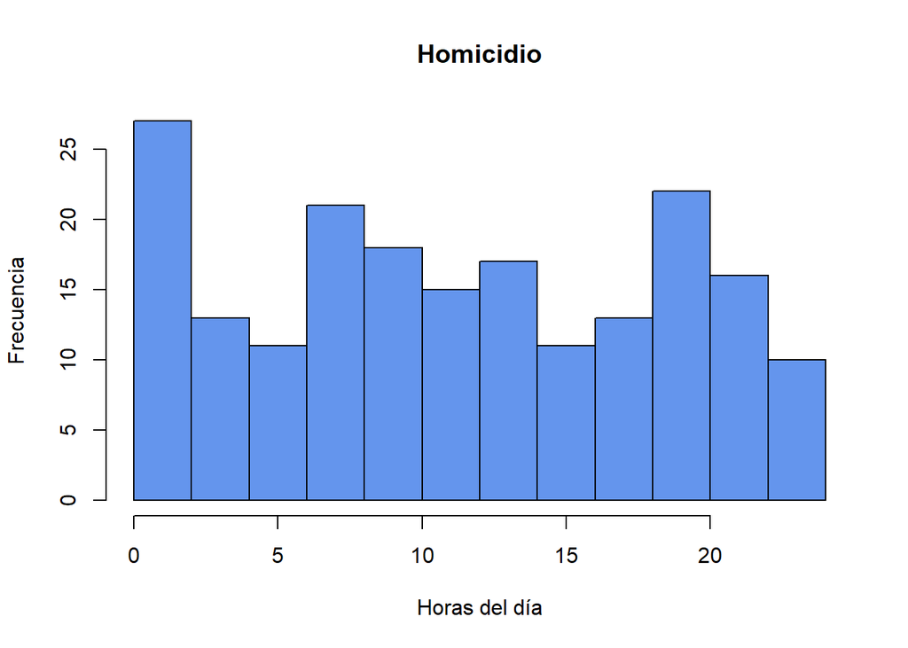

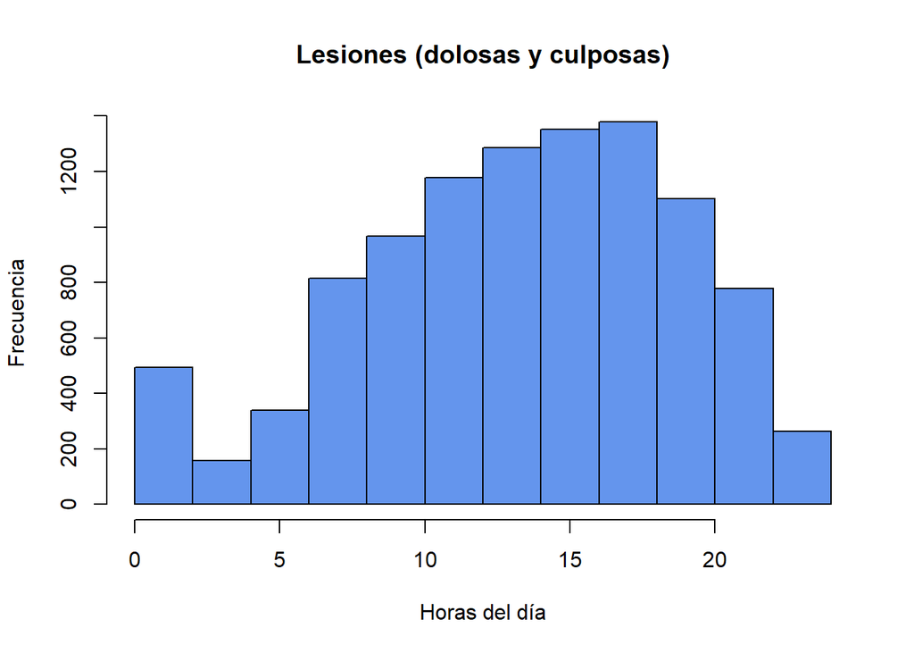

```r
Lista_tipo_delito <- unique(mi_data_frame$tipo_delito)

for (tipo in Lista_tipo_delito) {
  mi_data_frame_homicidio <- subset(mi_data_frame, tipo_delito == tipo)

  hist(mi_data_frame_homicidio$franja_horaria,col = "cornflowerblue",
     xlab = "Horas del día", ylab = "Frecuencia",
     main = tipo)
}
```

- **Visualización de datos*:***

  **Mapas de los hechos delictivos**

```r
#install.packages("sf")
library(sf)
```

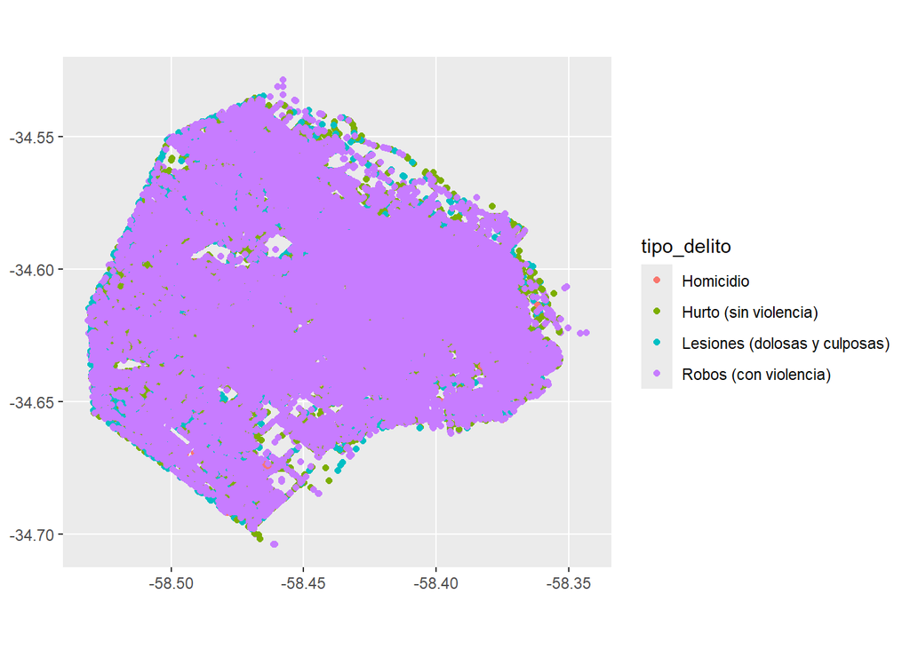

```r
mi_data_frame_filtrado <- subset(mi_data_frame, long != 0)

puntos_sf <- st_as_sf(mi_data_frame_filtrado, coords = c("long", "lat"))

ggplot() +
  geom_sf(data = puntos_sf, aes(color = tipo_delito))
```

**Mapas de los hechos delictivos por barrios:**

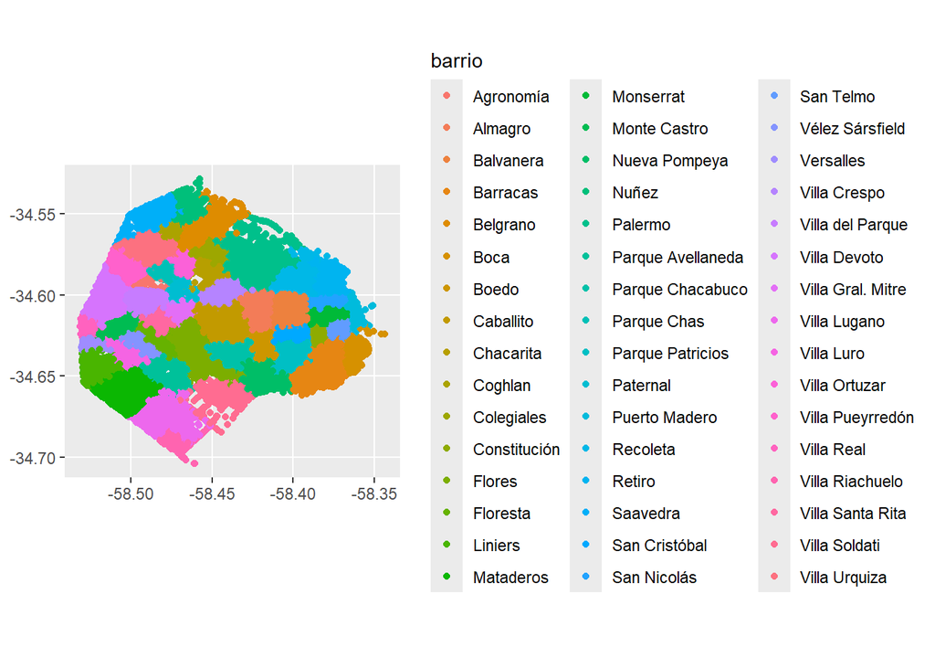

```r
mi_data_frame_filtrado <- subset(mi_data_frame, long != 0)

ggplot() +
  geom_sf(data = puntos_sf, aes(color = barrio))
```

- **Análisis de series temporales:**

  ```r
  #Nueva variable Mes del data frame en función de la fecha del echo delictivo
  mi_data_frame$Mes <- format(mi_data_frame$fecha, "%B")
  #Nueva variable Dia del data frame en función de la fecha del echo delictivo
  mi_data_frame$Dia <- weekdays(mi_data_frame$fecha)
  ```

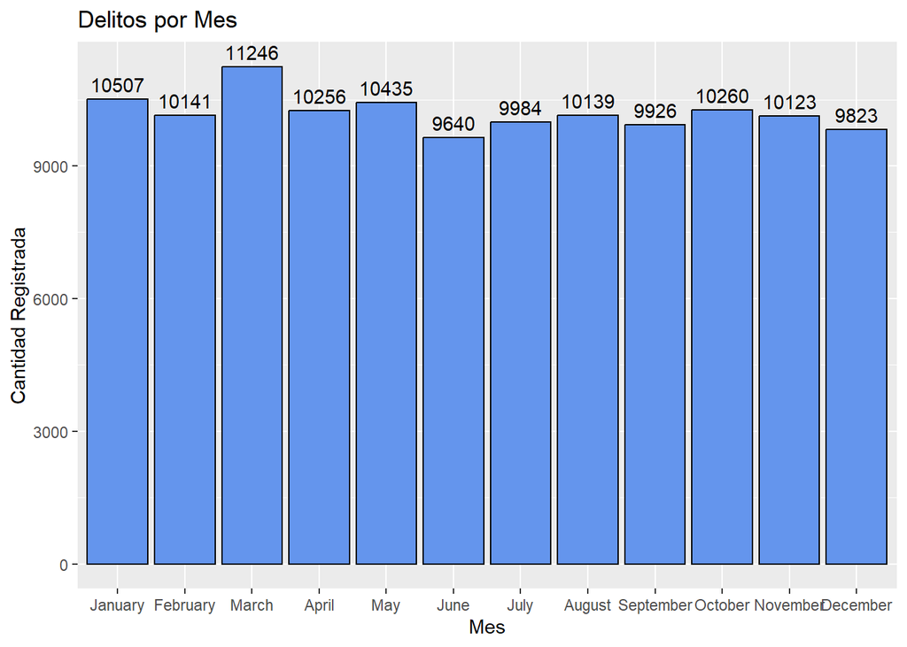

```r
ggplot(data = mi_data_frame, aes(Mes)) +
  geom_bar(fill = "cornflowerblue",
           color="black") +
  scale_x_discrete(limits = c("January", "February", "March", "April", "May", "June",
                              "July", "August", "September", "October", "November", "December")) +
  geom_text(stat = "count", aes(label = after_stat(count)), vjust = -0.5) +
  labs(x = "Mes",
       y = "Cantidad Registrada",
       title = "Delitos por Mes")
```

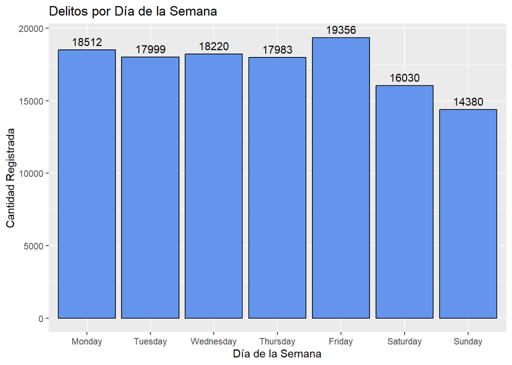

```r
ggplot(data = mi_data_frame, aes(Dia)) +
  geom_bar(fill = "cornflowerblue",
           color="black")+
   scale_x_discrete(limits = c("Monday", "Tuesday", "Wednesday", "Thursday", "Friday", "Saturday", "Sunday")) +
  geom_text(stat = "count", aes(label = after_stat(count)), vjust = -0.5) +
  labs(x = "Día de la Semana",
       y = "Cantidad Registrada",
       title = "Delitos por Día de la Semana")
```

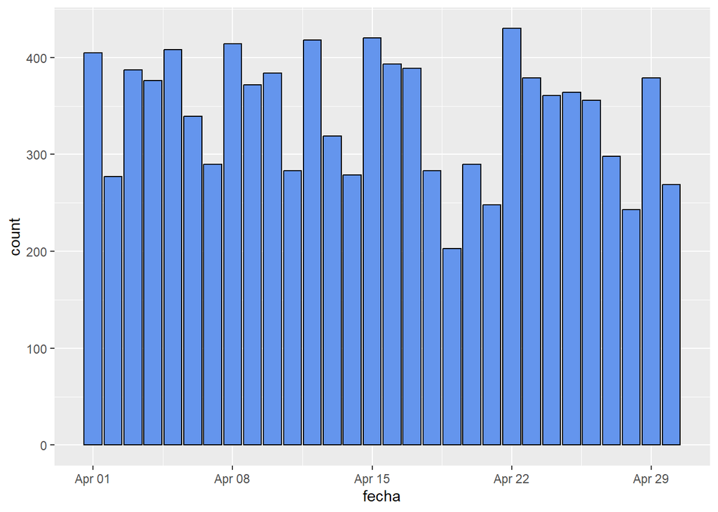

```r
mi_data_frame_filtrado <- subset(mi_data_frame, Mes == "April")

ggplot(data = mi_data_frame_filtrado, aes(fecha)) +
geom_bar(fill = "cornflowerblue",
           color="black")
```

## Interpretación y Conclusiones

**En resumen, el estudio proporciona una visión detallada de los patrones temporales de delitos en CABA, destacando la necesidad de estrategias de seguridad pública y prevención del delito que sean sensibles a las variaciones en la actividad delictiva a lo largo del tiempo y el espacio en la ciudad.**